# Data manipulation with dplyr

Joshua Catalano

## Aims of this worksheet

One of the key reasons to use R is to be able to manipulate data with ease. After completing this worksheet you will be able to work with the most commonly used data manipulation verbs provided by the dplyr and tidyr packages.

We will begin by loading the necessary packages and data. We will use the `methodists` dataset from the historydata package. This dataset contains membership figures for Methodist meetings (which were organized into districts, which were in turn organized into conferences) for the early nineteenth century.

```r
library(tidyverse)
```

```r
library(historydata)
data(methodists)
methodists
```

```
## # A tibble: 20,241 × 11
##     year conference district      meeting state members_total
##    <int>      <chr>    <chr>        <chr> <chr>         <int>
## 1   1786       <NA>     <NA>   Portsmouth  <NA>           356
## 2   1786       <NA>     <NA>       Sussex  <NA>           488
## 3   1786       <NA>     <NA>    Brunswick  <NA>           364
## 4   1786       <NA>     <NA>       Amelia  <NA>           412
## 5   1786       <NA>     <NA>  Mecklenburg  <NA>           429
## 6   1786       <NA>     <NA>      Bedford  <NA>           540
## 7   1786       <NA>     <NA>       Orange  <NA>           449
## 8   1786       <NA>     <NA> Williamsburg  <NA>           178
## 9   1786       <NA>     <NA>    Alleghany  <NA>           368
## 10  1786       <NA>     <NA>      Berkley  <NA>           166
## # ... with 20,231 more rows, and 5 more variables: members_general <int>,
## #   members_white <int>, members_black <int>, members_indian <int>,
## #   url <chr>
```

## Selecting columns (`select()`)

The first data manipulation verb that we are going to use is `select()`. This function lets us pass the names of the columns that we want to keep.

```r
methodists %>%
  select(year, meeting, members_total)
```

```
## # A tibble: 20,241 × 3
##     year      meeting members_total
##    <int>        <chr>         <int>
## 1   1786   Portsmouth           356
## 2   1786       Sussex           488
## 3   1786    Brunswick           364
## 4   1786       Amelia           412
## 5   1786  Mecklenburg           429
## 6   1786      Bedford           540
## 7   1786       Orange           449
## 8   1786 Williamsburg           178
## 9   1786    Alleghany           368
## 10  1786      Berkley           166
## # ... with 20,231 more rows
```

Notice that we have not actually changed the data stored in `methodists` until we assign the changed data to a variable.

Read the documentation for this function, `?select`.

1. Select the columns for `year`, `meeting`, as well as all columns that begin with the word `members_`.

```r
methodists %>%
  select(year, meeting, starts_with("members"))
```

```
## # A tibble: 20,241 × 7
##     year      meeting members_total members_general members_white
##    <int>        <chr>         <int>           <int>         <int>
## 1   1786   Portsmouth           356              NA           330
## 2   1786       Sussex           488              NA           416
## 3   1786    Brunswick           364              NA           305
## 4   1786       Amelia           412              NA           382
## 5   1786  Mecklenburg           429              NA           392
## 6   1786      Bedford           540              NA           524
## 7   1786       Orange           449              NA           374
## 8   1786 Williamsburg           178              NA           167
## 9   1786    Alleghany           368              NA           350
## 10  1786      Berkley           166              NA           140
## # ... with 20,231 more rows, and 2 more variables: members_black <int>,
## #   members_indian <int>
```

2. Remove the column `url`.

```r
methodists %>%
  select(year:members_indian)
```

```
## # A tibble: 20,241 × 10
##     year conference district      meeting state members_total
##    <int>      <chr>    <chr>        <chr> <chr>         <int>
## 1   1786       <NA>     <NA>   Portsmouth  <NA>           356
## 2   1786       <NA>     <NA>       Sussex  <NA>           488
## 3   1786       <NA>     <NA>    Brunswick  <NA>           364
## 4   1786       <NA>     <NA>       Amelia  <NA>           412
## 5   1786       <NA>     <NA>  Mecklenburg  <NA>           429
## 6   1786       <NA>     <NA>      Bedford  <NA>           540
## 7   1786       <NA>     <NA>       Orange  <NA>           449
## 8   1786       <NA>     <NA> Williamsburg  <NA>           178
## 9   1786       <NA>     <NA>    Alleghany  <NA>           368
## 10  1786       <NA>     <NA>      Berkley  <NA>           166
## # ... with 20,231 more rows, and 4 more variables: members_general <int>,
## #   members_white <int>, members_black <int>, members_indian <int>
```

## Filtering rows (`filter()`)

The `select()` function lets us pick certain columns. The `filter()` function lets select certain rows based on logical conditions. For example, here we get the only the meetings where the total number of members is at greater than 1,000.

```r
methodists %>%
  filter(members_total > 1000)
```

```
## # A tibble: 1,891 × 11
##     year conference district     meeting state members_total
##    <int>      <chr>    <chr>       <chr> <chr>         <int>
## 1   1786       <NA>     <NA>        Kent  <NA>          1013
## 2   1787       <NA>     <NA>        Kent  <NA>          1211
## 3   1787       <NA>     <NA>      Talbot  <NA>          1601
## 4   1788       <NA>     <NA>      Sussex  <NA>          1611
## 5   1788       <NA>     <NA>   Brunswick  <NA>          1604
## 6   1788       <NA>     <NA> Mecklenburg  <NA>          1109
## 7   1788       <NA>     <NA>     Calvert  <NA>          1347
## 8   1788       <NA>     <NA>   Baltimore  <NA>          1219
## 9   1788       <NA>     <NA>        Kent  <NA>          1600
## 10  1788       <NA>     <NA>      Talbot  <NA>          1601
## # ... with 1,881 more rows, and 5 more variables: members_general <int>,
## #   members_white <int>, members_black <int>, members_indian <int>,
## #   url <chr>
```

3. Get just the rows from New York in 1800.

```r
methodists %>%
  filter(state == "New York") %>%
  filter(year == 1800)
```

```
## # A tibble: 18 × 11
##     year conference district                 meeting    state
##    <int>      <chr>    <chr>                   <chr>    <chr>
## 1   1800       <NA>     <NA>             Albany City New York
## 2   1800       <NA>     <NA>          Albany Circuit New York
## 3   1800       <NA>     <NA>                Brooklyn New York
## 4   1800       <NA>     <NA>               Cambridge New York
## 5   1800       <NA>     <NA>                Chenango New York
## 6   1800       <NA>     <NA>                Columbia New York
## 7   1800       <NA>     <NA>                Delaware New York
## 8   1800       <NA>     <NA>                Dutchess New York
## 9   1800       <NA>     <NA>                Herkimer New York
## 10  1800       <NA>     <NA>             Long Island New York
## 11  1800       <NA>     <NA>                  Mohawk New York
## 12  1800       <NA>     <NA>                 Newburg New York
## 13  1800       <NA>     <NA> New Rochelle and Croton New York
## 14  1800       <NA>     <NA>                New York New York
## 15  1800       <NA>     <NA>       Oneida and Cayuga New York
## 16  1800       <NA>     <NA>              Plattsburg New York
## 17  1800       <NA>     <NA>                Saratoga New York
## 18  1800       <NA>     <NA>                  Seneca New York
## # ... with 6 more variables: members_total <int>, members_general <int>,
## #   members_white <int>, members_black <int>, members_indian <int>,
## #   url <chr>
```

4. Which Methodist meetings had only black members?

```r
methodists %>%
  filter(members_total == members_black)
```

```
## # A tibble: 121 × 11
##     year conference   district           meeting         state
##    <int>      <chr>      <chr>             <chr>         <chr>
## 1   1786       <NA>       <NA>           Antigua          <NA>
## 2   1787       <NA>       <NA>            Bladen          <NA>
## 3   1788       <NA>       <NA>             Cecil          <NA>
## 4   1793       <NA>       <NA>           Amherst          <NA>
## 5   1796       <NA>       <NA>              Bath         Maine
## 6   1796       <NA>       <NA>          Vershire       Vermont
## 7   1796       <NA>       <NA>            Croton      New York
## 8   1796       <NA>       <NA>     Staten Island      New York
## 9   1800       <NA>       <NA> Martha's Vineyard Massachusetts
## 10  1802   New York Pittsfield        Grand Isle          <NA>
## # ... with 111 more rows, and 6 more variables: members_total <int>,
## #   members_general <int>, members_white <int>, members_black <int>,
## #   members_indian <int>, url <chr>
```

5. Bonus: some of these Methodist meetings were “missions.” Load the `stringr` package and look at the documentation for `?str_detect`. Can you find which rows represent missions?

```r
library(stringr)
methodists %>%
  filter(str_detect(meeting, ignore.case("mission")))
```

```
## Please use (fixed|coll|regex)(x, ignore_case = TRUE) instead of ignore.case(x)
```

```
## # A tibble: 222 × 11
##     year     conference     district                   meeting state
##    <int>          <chr>        <chr>                     <chr> <chr>
## 1   1822        Genesee Upper Canada Mission to New Settlement  <NA>
## 2   1823           Ohio      Lebanon            Indian Mission  <NA>
## 3   1823 South Carolina      Catawba      Early county mission  <NA>
## 4   1823        Genesee Upper Canada       Grand River mission  <NA>
## 5   1824           Ohio      Lebanon            Indian mission  <NA>
## 6   1824       Kentucky   Cumberland        Cumberland mission  <NA>
## 7   1824      Tennessee   Huntsville Cherokee mission, Indiana  <NA>
## 8   1824 South Carolina       Athens            Monroe mission  <NA>
## 9   1824 South Carolina       Athens      Yellow River mission  <NA>
## 10  1824 South Carolina       Athens          Gwinnett mission  <NA>
## # ... with 212 more rows, and 6 more variables: members_total <int>,
## #   members_general <int>, members_white <int>, members_black <int>,
## #   members_indian <int>, url <chr>
```

## Creating new columns (`mutate()`)

Very often one will want to create a new column based on other columns in the data. For instance, in our Methodist data, there is a column called `year`, but that column represents the year that the minutes were reported. The membership figures are actually for the previous year. Here we create a new column called `year_recorded`, where each value is one less than in `year`.

```r
methodists %>%
  mutate(year_recorded = year - 1) %>%
  select(year, year_recorded, meeting)
```

```
## # A tibble: 20,241 × 3
##     year year_recorded      meeting
##    <int>         <dbl>        <chr>
## 1   1786          1785   Portsmouth
## 2   1786          1785       Sussex
## 3   1786          1785    Brunswick
## 4   1786          1785       Amelia
## 5   1786          1785  Mecklenburg
## 6   1786          1785      Bedford
## 7   1786          1785       Orange
## 8   1786          1785 Williamsburg
## 9   1786          1785    Alleghany
## 10  1786          1785      Berkley
## # ... with 20,231 more rows
```

Notice that we chained the data manipulation functions using the pipe (`%>%`). This lets us create a pipeline were we can do many different manipulations in a row.

6. Create two new columns, one with the percentage of white members, and one with the percentage of black members.

```r
methodists2 <- methodists %>%
  mutate(percentage_white = members_white/members_total) %>%
  mutate(percentage_black = members_black/members_total)
```

## Sorting columns (`arrange()`)

Often we want to sort a data frame by one of its columns. This can be done with the verb `arrange()`. By default `arrange()` will sort from least to greatest; we can use the function `desc()` to sort from greatest to least. In this example, we sort the data frame to get the meetings with the highest number of white members.

```r
methodists %>%
  arrange(desc(members_white))
```

```
## # A tibble: 20,241 × 11
##     year conference  district        meeting state members_total
##    <int>      <chr>     <chr>          <chr> <chr>         <int>
## 1   1825       Ohio Lancaster      Muskingum  <NA>          7775
## 2   1832   New York  New York       New York  <NA>          5355
## 3   1831   New York  New York       New York  <NA>          4953
## 4   1830   New York  New York       New York  <NA>          3955
## 5   1829   New York  New York       New York  <NA>          3839
## 6   1831  Baltimore Baltimore      Baltimore  <NA>          3764
## 7   1834  Baltimore Baltimore Baltimore city  <NA>          3740
## 8   1833  Baltimore Baltimore Baltimore city  <NA>          3700
## 9   1832  Baltimore Baltimore      Baltimore  <NA>          3622
## 10  1828   New York  New York       New York  <NA>          3477
## # ... with 20,231 more rows, and 5 more variables: members_general <int>,
## #   members_white <int>, members_black <int>, members_indian <int>,
## #   url <chr>
```

7. Which meetings had the highest number of black members? Select only the necessary columns so that the results print in a meaningful way.

```r
methodists %>%
  arrange(desc(members_black)) %>%
  select(meeting, members_black)
```

```
## # A tibble: 20,241 × 2
##       meeting members_black
##         <chr>         <int>
## 1  Charleston          5699
## 2  Charleston          5313
## 3  Charleston          3796
## 4  Charleston          3629
## 5  Charleston          3604
## 6  Charleston          3418
## 7  Charleston          3354
## 8  Charleston          3249
## 9  Charleston          3221
## 10 Charleston          3163
## # ... with 20,231 more rows
```

8. Which meetings had the high percentage of black members without being entirely black?

```r
methodists2 %>%
  arrange(desc(percentage_black)) %>%
  filter(percentage_black != 1.00) %>%
  select(year, meeting, percentage_black)
```

```
## # A tibble: 20,120 × 3
##     year                           meeting percentage_black
##    <int>                             <chr>            <dbl>
## 1   1834              Combahee and Pon Pon        0.9854949
## 2   1799                        Georgetown        0.9627660
## 3   1798                        Georgetown        0.9625668
## 4   1816                        Georgetown        0.9581182
## 5   1800                        Georgetown        0.9570815
## 6   1833 Mission to slaves near Charleston        0.9540126
## 7   1801                        Georgetown        0.9503311
## 8   1815                        Georgetown        0.9501823
## 9   1805                        Wilmington        0.9484778
## 10  1828                        Georgetown        0.9478944
## # ... with 20,110 more rows
```

## Split-apply-combine (`group_by()`)

We can solve this kind of problem with what Hadley Wickham calls the “split-apply-combine” pattern of data analysis. Think of it this way. First we can *split* the big data frame into separate data frames, one for each year. Then we can *apply* our logic to get the results we want; in this case, that means sorting the data frame. We might also want to get just the top one row with the biggest number of members. Then we can *combine* those split apart data frames into a new data frame.

Take a simple example using the `top_n()` function, which returns the top `n` (in this case, top 1) results for a particular column. After selecting a few columns, we get the row in the data frame which has the highest value for `members_black`.

```r
methodists %>%
  select(year, meeting, members_total, members_black) %>%
  top_n(1, members_black)
```

```
## # A tibble: 1 × 4
##    year    meeting members_total members_black
##   <int>      <chr>         <int>         <int>
## 1  1817 Charleston          6049          5699
```

We can change how that code works by using the `group_by()` function. Now we get the one row for each unique year in the dataset.

```r
methodists %>%
  select(year, meeting, members_total, members_black) %>%
  group_by(year) %>%
  top_n(1, members_black)
```

```
## Source: local data frame [49 x 4]
## Groups: year [49]
##
##     year meeting members_total members_black
##    <int>   <chr>         <int>         <int>
## 1   1786 Antigua          1000          1000
## 2   1787    Kent          1211           604
## 3   1788 Calvert          1347           842
## 4   1789 Calvert          1852           909
## 5   1790 Calvert          1984          1170
## 6   1791 Calvert          2089          1329
## 7   1792 Calvert          1900          1200
## 8   1793   Surry          1769           955
## 9   1794 Calvert          1784          1102
## 10  1795 Calvert          1526           924
## # ... with 39 more rows
```

We get the same results more concisely and reliably, though the steps of “split-apply-combine” are perhaps somewhat less easy to see.

9. For each year, which was the biggest circuit?

```r
methodists %>%
  select(year, meeting, members_total) %>%
  group_by(year) %>%
  top_n(1, members_total)
```

```
## Source: local data frame [49 x 3]
## Groups: year [49]
##
##     year meeting members_total
##    <int>   <chr>         <int>
## 1   1786    Kent          1013
## 2   1787  Talbot          1601
## 3   1788  Sussex          1611
## 4   1789 Calvert          1852
## 5   1790 Calvert          1984
## 6   1791 Calvert          2089
## 7   1792 Calvert          1900
## 8   1793   Surry          1769
## 9   1794  Sussex          2354
## 10  1795 Calvert          1526
## # ... with 39 more rows
```

10. For each year, which church had the biggest percentage of black members without being entirely black?

```r
methodists2 %>%
  filter(percentage_black != 1.00) %>%
  select(year, meeting, percentage_black) %>%
  group_by(year) %>%
  top_n(1, percentage_black)
```

```
## Source: local data frame [50 x 3]
## Groups: year [49]
##
##     year         meeting percentage_black
##    <int>           <chr>            <dbl>
## 1   1786         Calvert        0.5171849
## 2   1787      Charleston        0.6091954
## 3   1788         Calvert        0.6250928
## 4   1789     Mecklenburg        0.8759494
## 5   1790       Annapolis        0.6026059
## 6   1791      Charleston        0.6432432
## 7   1792      Georgetown        0.6711409
## 8   1793 Prince George's        0.7758621
## 9   1793      Georgetown        0.7758621
## 10  1794      Charleston        0.7857143
## # ... with 40 more rows
```

11. For the year 1825, what was the biggest meeting in each conference? In each district?

```r
methodists %>%
  filter(year == 1825) %>%
  select(year, conference, members_total) %>%
  group_by(conference) %>%
  top_n(1, members_total)
```

```
## Source: local data frame [15 x 3]
## Groups: conference [15]
##
##     year     conference members_total
##    <int>          <chr>         <int>
## 1   1825           Ohio          7775
## 2   1825       Kentucky          1050
## 3   1825       Missouri          1000
## 4   1825      Tennessee          1225
## 5   1825        Holston          1922
## 6   1825    Mississippi           981
## 7   1825 South Carolina          3178
## 8   1825       Virginia          1686
## 9   1825      Baltimore          4024
## 10  1825   Philadelphia          2055
## 11  1825       New York          2623
## 12  1825    New England           684
## 13  1825          Maine           668
## 14  1825        Genesee          1009
## 15  1825         Canada           590
```

```r
methodists %>% filter(year == 1825)  %>%
  select(year, district, members_total) %>%
  group_by(district) %>%
  top_n(1, members_total)
```

```
## Source: local data frame [74 x 3]
## Groups: district [74]
##
##     year    district members_total
##    <int>       <chr>         <int>
## 1   1825        Ohio           701
## 2   1825    Portland           785
## 3   1825   Lancaster          7775
## 4   1825   Muskingum          1090
## 5   1825      Scioto          1022
## 6   1825     Lebanon          1419
## 7   1825       Miami           906
## 8   1825     Kenhawa           648
## 9   1825     Augusta           930
## 10  1825 Green River           734
## # ... with 64 more rows
```

12. For each year, what was the biggest church in the Baltimore conference?

```r
methodists %>%
  select(year, conference, meeting, members_total) %>%
  filter(conference == "Baltimore") %>%
  group_by(year) %>%
  top_n(1, members_total)
```

```
## Source: local data frame [33 x 4]
## Groups: year [33]
##
##     year conference meeting members_total
##    <int>      <chr>   <chr>         <int>
## 1   1802  Baltimore Calvert          1612
## 2   1803  Baltimore Calvert          2052
## 3   1804  Baltimore Calvert          2457
## 4   1805  Baltimore Calvert          2531
## 5   1806  Baltimore Calvert          2421
## 6   1807  Baltimore Calvert          2544
## 7   1808  Baltimore Calvert          2273
## 8   1809  Baltimore Calvert          2182
## 9   1810  Baltimore Calvert          2303
## 10  1811  Baltimore Calvert          2198
## # ... with 23 more rows
```

## Summarizing or aggregating data (`summarize()`)

In the examples using `top_n()` we performed a very simple kind of data summary, where we took the single row with the biggest value in a given column. This essentially boiled many rows of a data frame down into a single row. We would like to be able to summarize or aggregate a data frame in other ways as well. For instance, we often want to take the sum or the mean of a given column. We can do this using the `summarize()` function in conjunction with the `group_by()` function.

In this example, we group by the year the minutes were taken. Then we find the total number of white members for each year.

```r
methodists %>%
  group_by(year) %>%
  summarize(total_members_white = sum(members_white, na.rm = TRUE))
```

```
## # A tibble: 49 × 2
##     year total_members_white
##    <int>               <int>
## 1   1786               18291
## 2   1787               21949
## 3   1788               30557
## 4   1789               34425
## 5   1790               45983
## 6   1791               50580
## 7   1792               52079
## 8   1793               51486
## 9   1794               52794
## 10  1795               48121
## # ... with 39 more rows
```

Notice that we get one row in the recombined data frame for each group in the original data frame. The value in the new column is the result of a function (in this case, `sum()`) applied to the columns in each of the split apart data frames.

There is also a special case where we might want to know how many rows were in each of the split apart (or grouped) data frames. We can use the special `n()` function to get that count. (This is such a common thing to do that dplyr provides the special function `count()` to do this in an abbreviated way. You can look up that function’s documentation to see how it works.)

```r
methodists %>%
  group_by(year) %>%
  summarize(total_meetings = n())
```

```
## # A tibble: 49 × 2
##     year total_meetings
##    <int>          <int>
## 1   1786             51
## 2   1787             55
## 3   1788             76
## 4   1789             84
## 5   1790             99
## 6   1791            126
## 7   1792            135
## 8   1793            141
## 9   1794            146
## 10  1795            136
## # ... with 39 more rows
```

13. How many meetings were there in each conference in each year since 1802?

```r
methodists %>%
  filter(year >= 1802) %>%
  select(year, conference) %>%
  group_by(conference, year) %>%
    summarize(total_meetings = n())
```

```
## Source: local data frame [389 x 3]
## Groups: conference [?]
##
##    conference  year total_meetings
##         <chr> <int>          <int>
## 1     Alabama  1833             22
## 2     Alabama  1834             28
## 3   Baltimore  1802             30
## 4   Baltimore  1803             30
## 5   Baltimore  1804             37
## 6   Baltimore  1805             39
## 7   Baltimore  1806             39
## 8   Baltimore  1807             46
## 9   Baltimore  1808             42
## 10  Baltimore  1809             41
## # ... with 379 more rows
```

14. What is the average number of white, black, Indian and total members for each year since 1786?

```r
methodists %>%
  filter(year >= 1786) %>%
  group_by(year) %>%
  summarize(avg_num_white = mean(members_white), avg_num_black = mean(members_black), avg_num_indian = mean(members_indian))
```

```
## # A tibble: 49 × 4
##     year avg_num_white avg_num_black avg_num_indian
##    <int>         <dbl>         <dbl>          <dbl>
## 1   1786      358.6471      56.66667              0
## 2   1787      399.0727      70.60000              0
## 3   1788      402.0658     105.14474              0
## 4   1789      409.8214     105.23810              0
## 5   1790      464.4747     118.00000              0
## 6   1791      401.4286     103.95238              0
## 7   1792      385.7704     102.74815              0
## 8   1793      365.1489     102.26950              0
## 9   1794      361.6027      95.24658              0
## 10  1795      353.8309      89.49265              0
## # ... with 39 more rows
```

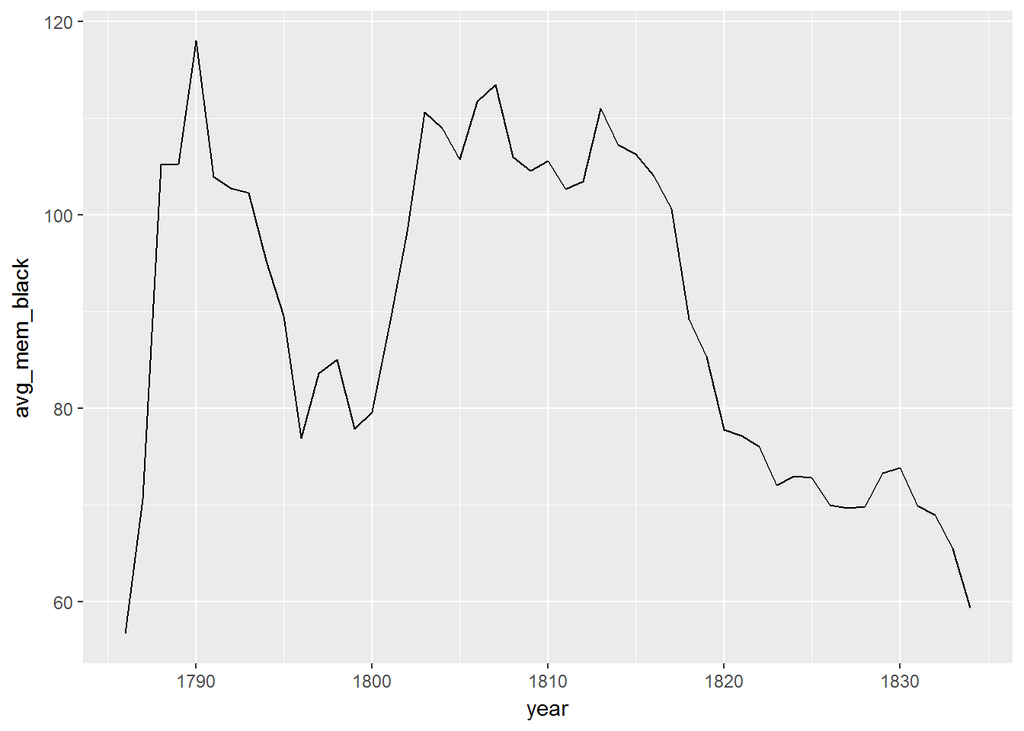

```r
methodists %>%
  group_by(year) %>%
  summarize(avg_mem_black = mean(members_black, na.rm = TRUE)) %>%
  ggplot(aes(x = year, y = avg_mem_black)) +
  geom_line()
```

16. Make a plot of the average and median number of members over time.

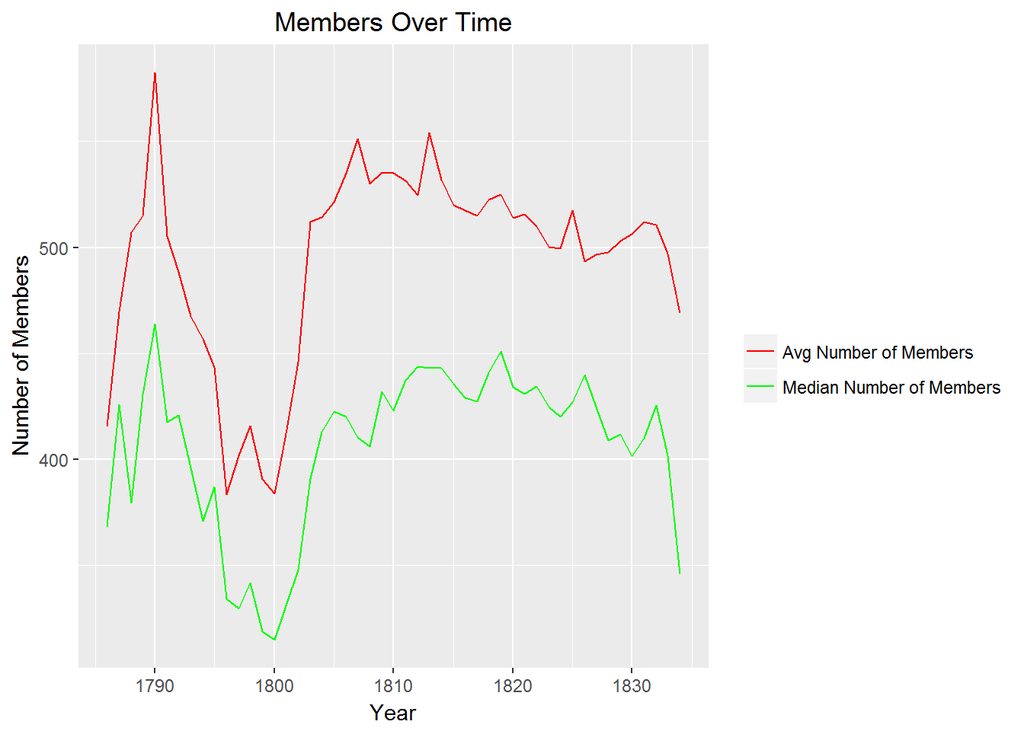

```r
methodists %>%
  group_by(year) %>%
  summarize(avg_members = mean(members_total), median_members = median(members_total, na.rm=TRUE)) %>%
ggplot(aes(x = year)) +
  geom_line(aes(y = avg_members, color="Avg Number of Members")) +
  geom_line(aes(y = median_members, color="Median Number of Members")) +
  scale_colour_manual("", values = c("red", "green")) +
  labs(title= "Members Over Time", y = "Number of Members",
       x = "Year") +
   theme(plot.title = element_text(hjust = 0.5))
```

17. What was the average number of members in each conference for each year? Can you also make a plot of this?

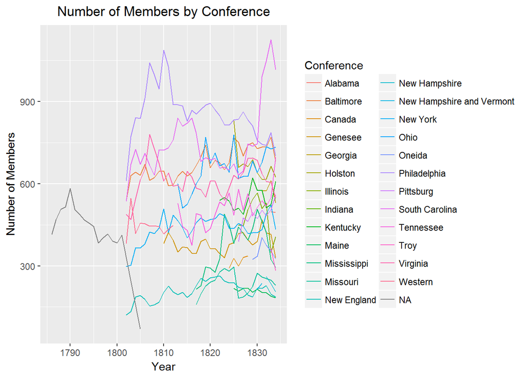

```r
methodists %>%
  group_by(conference, year) %>%
  summarize(avg_num_conf = mean(members_total)) %>%
  ggplot(aes(x = year, y = avg_num_conf, color= conference)) +
  geom_line() +
  labs( y = "Number of Members", x = "Year", title = "Number of Members by Conference", color = "Conference") +
  theme(plot.title = element_text(hjust = 0.5))
```

> OR

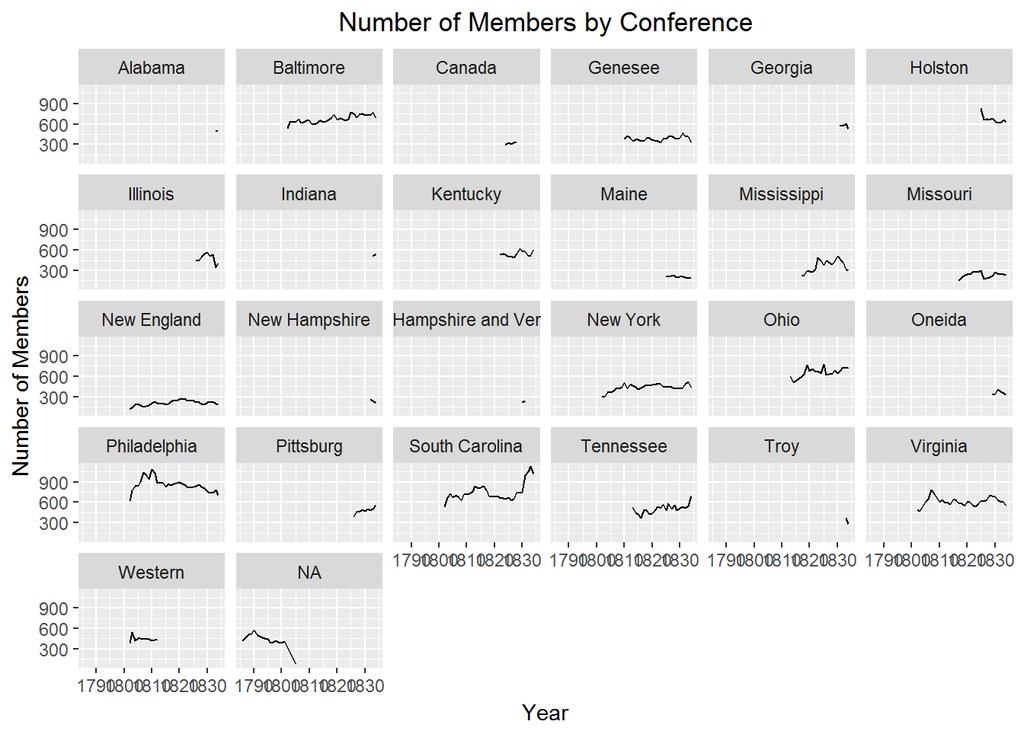

```r
methodists %>%
  group_by(conference, year) %>%
  summarize(avg_num_conf = mean(members_total)) %>%
  ggplot(aes(x = year, y = avg_num_conf)) +
  geom_line() +
  labs( y = "Number of Members", x = "Year", title = "Number of Members by Conference") +
  theme(plot.title = element_text(hjust = 0.5)) +
  facet_wrap(~conference)
```

18. What was the average percentage of black members in each conference for each year? Can you also make a plot of this?

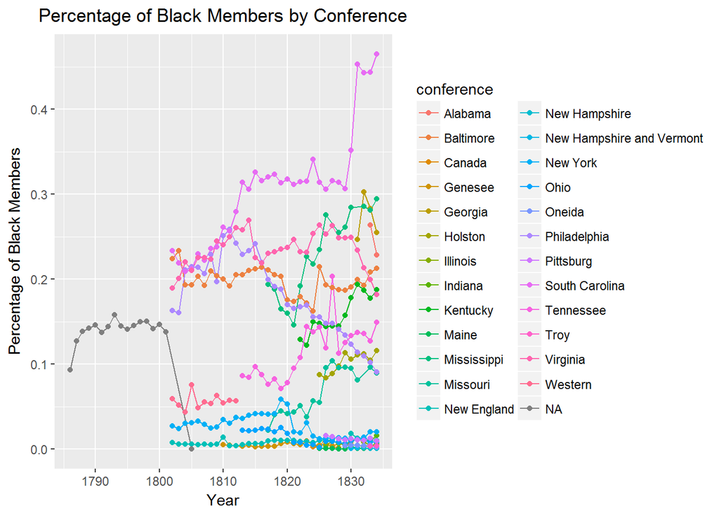

```r
methodists %>%
  group_by(conference, year) %>%
  summarize(percentage_black = mean(members_black/members_total, na.rm = TRUE)) %>%
  ggplot(aes(x = year, y = percentage_black, color = conference)) +
  geom_line() +
  geom_point() +
  labs(y = "Percentage of Black Members", x = "Year", title = "Percentage of Black Members by Conference") +
    theme(plot.title = element_text(hjust = 0.5))
```

> Or

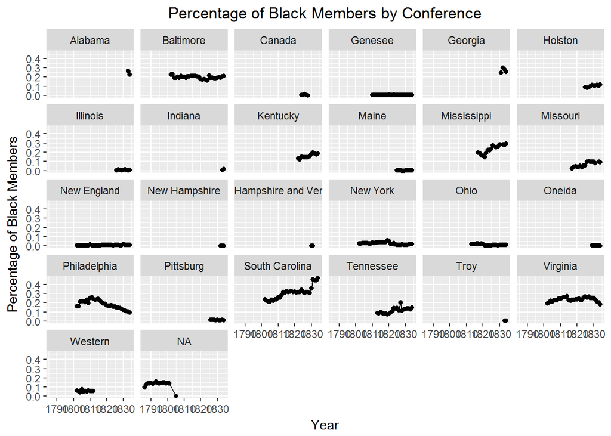

```r
methodists %>%
  group_by(conference, year) %>%
  summarize(percentage_black = mean(members_black/members_total, na.rm = TRUE)) %>%
  ggplot(aes(x = year, y = percentage_black)) +
  geom_line() +
  geom_point() +
   labs(y = "Percentage of Black Members", x = "Year", title = "Percentage of Black Members by Conference") +
    theme(plot.title = element_text(hjust = 0.5)) +
  facet_wrap(~conference)
```